# Machine Learning : Linear Regression VS One Neuron

Les bibliothèques suivantes sont à utiliser

```python
import numpy as np
import matplotlib.pyplot as plt
from sklearn.model_selection import train_test_split #split data ino training data and test data
import pandas as pnd
```

# I. Partie 1: Linear Regression

[figure not shown]

Un modèle de régression permet de faire la liaison entre la sortie et l'entrée de la manière suivante:

y=H(X). avec y est l'output et X est linput. En général X est une matrice (tableau à deux dimension avec plusieurs colonnes (variables) x1,x2...xn).

le modèle H à trouver a la forme suivante: H(X)=bias+w1.x1+w2.x2+...+wn.xn

dans un premier temps, pour simplifier, nous allons considérer un X avec une seule variable. dans ce cas, notre modèle a la forme suivante:

H(x1)=bias+w1.x1

qu'est ce que c'est l'apprentissage?

L'apprentissage est la capacité d'un algorithme de trouver les bons paramètres du modèle qui sont: bias et wi pour i allant de 1 à n, avec n le nombre de variables à l'input.

pour le cas d'une seule dimension, l'algorithme est cencé de trouver le bias et le bon w1

## I.1. Linear Regression Model: example

### I.1.1. Data

#### Step 1: Load / Initialize Data

```python
X=np.array([1,2,3,4,7]) #features
y=np.array([4,7,10,13,22]) #target
```

#### Step 2: Plot Data

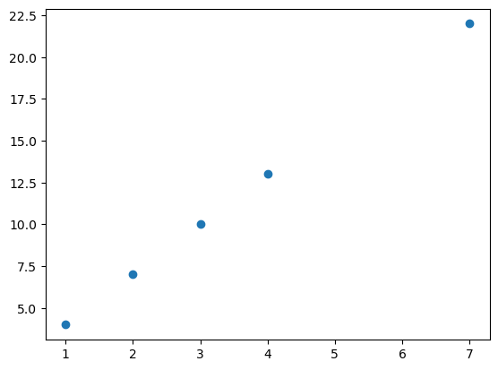

```python
plt.scatter(X,y)
```

#### Step 3: Split Data

pour évaluer la performance du modèle, il est nécessaire de tester le modèle ( calculer mse) sur des données non utilisées dans la phase d'apprentissage

Mais, pour cet exemple, le data set est de taille très petite, alors nous allons pas le diviser (split) en training set et et test set.

### I.1.2. Model (version 1 - without gradient descent)

#### Step 1: Model Training

le programme suivant permet de calculer l'erreur pour plusieurs couple (bias,w1). chaque couple (bias,w1) représente un modèle

pour simplifier, nous allons fixer bias

```python
def train1(X,y):
    #hyper parameters initailization
    epochs=60
    learning_rate=0.1 #
    #parameters initialization
    w1=0 #noter que cette valeur se trouve à gauche de l'optimum recherché (w1=3)
    bias=1 #pour simplifier, le bias est considéré trouvé: à ne pas mettre à jour

    global mseList
    mseList=[] #means squared error list pour chaque valeur de w1
    global w1List
    w1List=[] #les valeurs prises par w1 sont enregistrées dans w1List
    n=len(X)
    for i in range(epochs):
        yhat=bias+w1*X
        error=y-yhat # error
        squared_error=error**2 #squared error
        mse=(1/n)*sum(squared_error) #mean squared error
        print("iteration ",i,": (bias=",round(bias,2),",w1:",round(w1,2),") --->mse=",round(mse,2))

        mseList.append(mse)
        w1List.append(w1)

        dw1=0.1
        w1=w1+dw1

    return bias,w1

bias,w1=train1(X,y)
```

```
iteration  0 : (bias= 1 ,w1: 0 ) --->mse= 142.2
iteration  1 : (bias= 1 ,w1: 0.1 ) --->mse= 132.88
iteration  2 : (bias= 1 ,w1: 0.2 ) --->mse= 123.87
iteration  3 : (bias= 1 ,w1: 0.3 ) --->mse= 115.18
iteration  4 : (bias= 1 ,w1: 0.4 ) --->mse= 106.81
iteration  5 : (bias= 1 ,w1: 0.5 ) --->mse= 98.75
iteration  6 : (bias= 1 ,w1: 0.6 ) --->mse= 91.01
iteration  7 : (bias= 1 ,w1: 0.7 ) --->mse= 83.58
iteration  8 : (bias= 1 ,w1: 0.8 ) --->mse= 76.47
iteration  9 : (bias= 1 ,w1: 0.9 ) --->mse= 69.68
iteration  10 : (bias= 1 ,w1: 1.0 ) --->mse= 63.2
iteration  11 : (bias= 1 ,w1: 1.1 ) --->mse= 57.04
iteration  12 : (bias= 1 ,w1: 1.2 ) --->mse= 51.19
iteration  13 : (bias= 1 ,w1: 1.3 ) --->mse= 45.66
iteration  14 : (bias= 1 ,w1: 1.4 ) --->mse= 40.45
iteration  15 : (bias= 1 ,w1: 1.5 ) --->mse= 35.55
iteration  16 : (bias= 1 ,w1: 1.6 ) --->mse= 30.97
iteration  17 : (bias= 1 ,w1: 1.7 ) --->mse= 26.7
iteration  18 : (bias= 1 ,w1: 1.8 ) --->mse= 22.75
iteration  19 : (bias= 1 ,w1: 1.9 ) --->mse= 19.12
iteration  20 : (bias= 1 ,w1: 2.0 ) --->mse= 15.8
iteration  21 : (bias= 1 ,w1: 2.1 ) --->mse= 12.8
iteration  22 : (bias= 1 ,w1: 2.2 ) --->mse= 10.11
iteration  23 : (bias= 1 ,w1: 2.3 ) --->mse= 7.74
iteration  24 : (bias= 1 ,w1: 2.4 ) --->mse= 5.69
iteration  25 : (bias= 1 ,w1: 2.5 ) --->mse= 3.95
iteration  26 : (bias= 1 ,w1: 2.6 ) --->mse= 2.53
iteration  27 : (bias= 1 ,w1: 2.7 ) --->mse= 1.42
iteration  28 : (bias= 1 ,w1: 2.8 ) --->mse= 0.63
iteration  29 : (bias= 1 ,w1: 2.9 ) --->mse= 0.16
iteration  30 : (bias= 1 ,w1: 3.0 ) --->mse= 0.0
iteration  31 : (bias= 1 ,w1: 3.1 ) --->mse= 0.16
iteration  32 : (bias= 1 ,w1: 3.2 ) --->mse= 0.63
iteration  33 : (bias= 1 ,w1: 3.3 ) --->mse= 1.42
iteration  34 : (bias= 1 ,w1: 3.4 ) --->mse= 2.53
iteration  35 : (bias= 1 ,w1: 3.5 ) --->mse= 3.95
iteration  36 : (bias= 1 ,w1: 3.6 ) --->mse= 5.69
iteration  37 : (bias= 1 ,w1: 3.7 ) --->mse= 7.74
iteration  38 : (bias= 1 ,w1: 3.8 ) --->mse= 10.11
iteration  39 : (bias= 1 ,w1: 3.9 ) --->mse= 12.8
iteration  40 : (bias= 1 ,w1: 4.0 ) --->mse= 15.8
iteration  41 : (bias= 1 ,w1: 4.1 ) --->mse= 19.12
iteration  42 : (bias= 1 ,w1: 4.2 ) --->mse= 22.75
iteration  43 : (bias= 1 ,w1: 4.3 ) --->mse= 26.7
iteration  44 : (bias= 1 ,w1: 4.4 ) --->mse= 30.97
iteration  45 : (bias= 1 ,w1: 4.5 ) --->mse= 35.55
iteration  46 : (bias= 1 ,w1: 4.6 ) --->mse= 40.45
iteration  47 : (bias= 1 ,w1: 4.7 ) --->mse= 45.66
iteration  48 : (bias= 1 ,w1: 4.8 ) --->mse= 51.19
iteration  49 : (bias= 1 ,w1: 4.9 ) --->mse= 57.04
iteration  50 : (bias= 1 ,w1: 5.0 ) --->mse= 63.2
iteration  51 : (bias= 1 ,w1: 5.1 ) --->mse= 69.68
iteration  52 : (bias= 1 ,w1: 5.2 ) --->mse= 76.47
iteration  53 : (bias= 1 ,w1: 5.3 ) --->mse= 83.58
iteration  54 : (bias= 1 ,w1: 5.4 ) --->mse= 91.01
iteration  55 : (bias= 1 ,w1: 5.5 ) --->mse= 98.75
iteration  56 : (bias= 1 ,w1: 5.6 ) --->mse= 106.81
iteration  57 : (bias= 1 ,w1: 5.7 ) --->mse= 115.18
iteration  58 : (bias= 1 ,w1: 5.8 ) --->mse= 123.87
iteration  59 : (bias= 1 ,w1: 5.9 ) --->mse= 132.88
```

### Analyse du code et interprétation du résultat

### Graphe 1: Evolutionde mse en fonction de w1 et en fonction des itérations

```python
#cette fonction est utilisé dans tout le tutorial
def tracer_graphes(w1List,mseList,iterations):
    plt.figure(figsize=(10,3))
    plt.subplot(121) #
    plt.plot(w1List,mseList)
    plt.xlabel("w1")
    plt.ylabel("mse")
    plt.title("mse en fonction de w1")
    plt.subplot(122)
    plt.plot(iterations,mseList)

    plt.xlabel("iteration")
    plt.ylabel("mse")
    plt.title("mse en fonction des iterations")
```

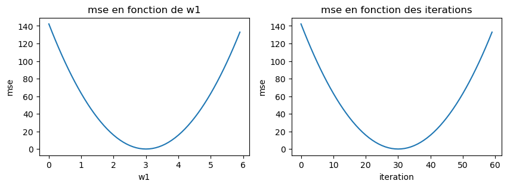

```python
tracer_graphes(w1List,mseList,[i for i in range(60)])
```

#### Step 2: Model Prediction

```python
def predict(x1):
    return bias+w1*x1
```

```python
yhat=predict(X)
```

#### Step 3: Model Evaluation

vu que le dataset est tres petit, nous allons utiliser le dataset de training (X) pour évaluer le modèle (bad practice)  
dans l'exemple suivant, nous allons utiliser un dataset de test pour évaluer le modèle

```python
def mse(y,yhat):
    return 1/(len(y))*np.sum((y-yhat)**2)
```

```python
print("mean squared error du modèle est:",round(mse(y,yhat),3))
```

```
mean squared error du modèle est: 142.2
```

```python
bias,round(w1,2)
```

```
(1, 6.0)
```

### questions

**1)** comment varie mse à partir de l'itération 0 à l'iération 30?

**2)** comment varie mse à partir de l'itération 30 à l'iération 59?

**3)** à quelle itération, mse est minimal?

**4)** comment se comporte l'algorithme si on initialise w1 à 6?

**5)** comment se comporte l'algorithme si dw1=2? (ou autre valeur plus grande que 2)

**6)** comment la dérivée partielle (dmse/dw1) permet de régler le problème en 4)? (Algorithme du gradient)

**7)** comment le learning rate permet de régler le problème en 5)?

**8)** justifier la valeur de mse trouvé?

### REPONSES

**1)** comment varie mse à partir de l'itération 0 à l'iération 30?

**Réponse**  
comme montré dans le graphe et à partir des valeurs imprimées pendant l'apprentissage,  
à l'iération 0, mse=142.2  
à l'itération 1, mse=132.88  
ensuite, mse continue à dminuer jusqu'à litération 30.  
à l'itération 30, mse=0

**2)** comment varie mse à partir de l'itération 30 à l'iération 59?

**Réponse**  
comme montré dans le graphe et à partir des valeurs imprimées pendant l'apprentissage  
à l'iération 30, mse=0  
à l'itération 31, mse=0.16  
ensuite, mse continue à augmenter jusqu'à litération 59.  
à l'itération 59, mse=132.88

**3)** à quelle itération, mse est minimal?

**Réponse**  
comme montré dans le graphe et à partir des valeurs imprimées pendant l'apprentissage,  
la valeur de mse est minimal (mse=0) à l'itération 30, et pour w1=3

**4)** comment se comporte l'algorithme si on initialise w1 à 6?

**Réponse**  
pour w1 initialisé à 6,  
si on analyse le programme, et exatement les deux instructions suivantes:  
dw1=0.1 w1=w1+dw1 #augmentation de w1  
la valeur de w1 va contnier à augmenter (s'éloigne de l'optimum w1=3)  
ce qui implique l'augmentation de mse (d'après les graphes)

**5)** comment se comporte l'algorithme si dw1=2? (ou autre valeur plus grande que 2)

**Réponse**  
pour dw1=2, et pour w1 initail (w1=0)  
à chaque itération, on ajoute à w1 la valeur 2: w1=0,2,4,6,8...  
ce qui montre que notre algorithme saute le minimum: le pas de mise à jour est grand

**6)** comment la dérivée partielle (dmse/dw1) permet de régler le problème en 4)? (Algorithme du gradient)

**Réponse**  
la dérivé partielle aide à trouver l'oientation de mise à jour: signe de la dérivée partielle  
si le signe est négative (w1 courant à gauche du w1 optimal (3)): mse diminue, donc aller vers la droite. w1=w1-dw1  
et puisque dw1 est négative, w1 va augmenter (ce qu'on cherche à faire)  
si le signe est positif (w1 courant à droite du w1 optimal (3)): mse augmente, donc aller vers la gauche. w1=w1-dw1  
et puisque dw1 est positif, w1 va diminuer (ce qu'on cherche à faire)

**7)** comment le learning rate permet de régler le problème en 5)?

**Réponse**  
le learning rate est une constante qui permet d'assurer des petits pas d'apprentissage pour éviter de sauter l'optimum  
cette valeur est à multiplier par dw1.  
sa valeur est toujours entre 0 et 1. en général, on met: learning_rate=0,1,0.01,0.001, ...selon les cas  
cette valeur affaiblit la quantité de mise à jour à appliquer sur w1.

**8)** justifier la valeur de mse trouvé?

**Réponse**  
mse affiché du modèle (bias,w1) est : 142.2  
cette valeur est grande à cause du modèle calculé par le program (bias=1,w1=6)  
un modèle loin de ce qu'on attend (bias=1,w1=3)

### I.1.3. Model (version 2- using gradient descent)

#### Step 1: Model Trainig

```
iteration  0 : (bias= 0 ,w1: 0 ) --->mse= 163.6  | update: dbias= -22.4 , dw1= -101.6
iteration  1 : (bias= 0.22 ,w1: 1.02 ) --->mse= 73.26419  | update: dbias= -15.04 , dw1= -67.97
iteration  2 : (bias= 0.37 ,w1: 1.7 ) --->mse= 32.81804  | update: dbias= -10.12 , dw1= -45.47
iteration  3 : (bias= 0.48 ,w1: 2.15 ) --->mse= 14.70895  | update: dbias= -6.83 , dw1= -30.41
iteration  4 : (bias= 0.54 ,w1: 2.45 ) --->mse= 6.60082  | update: dbias= -4.62 , dw1= -20.34
iteration  5 : (bias= 0.59 ,w1: 2.66 ) --->mse= 2.97042  | update: dbias= -3.15 , dw1= -13.6
iteration  6 : (bias= 0.62 ,w1: 2.79 ) --->mse= 1.34483  | update: dbias= -2.16 , dw1= -9.09
iteration  7 : (bias= 0.64 ,w1: 2.88 ) --->mse= 0.61685  | update: dbias= -1.5 , dw1= -6.07
iteration  8 : (bias= 0.66 ,w1: 2.95 ) --->mse= 0.29076  | update: dbias= -1.05 , dw1= -4.05
iteration  9 : (bias= 0.67 ,w1: 2.99 ) --->mse= 0.14462  | update: dbias= -0.76 , dw1= -2.7
iteration  10 : (bias= 0.68 ,w1: 3.01 ) --->mse= 0.07903  | update: dbias= -0.56 , dw1= -1.79
iteration  11 : (bias= 0.68 ,w1: 3.03 ) --->mse= 0.04952  | update: dbias= -0.43 , dw1= -1.19
iteration  12 : (bias= 0.69 ,w1: 3.04 ) --->mse= 0.03617  | update: dbias= -0.34 , dw1= -0.78
iteration  13 : (bias= 0.69 ,w1: 3.05 ) --->mse= 0.03004  | update: dbias= -0.28 , dw1= -0.51
iteration  14 : (bias= 0.69 ,w1: 3.06 ) --->mse= 0.02716  | update: dbias= -0.24 , dw1= -0.33
iteration  15 : (bias= 0.69 ,w1: 3.06 ) --->mse= 0.02573  | update: dbias= -0.21 , dw1= -0.21
iteration  16 : (bias= 0.7 ,w1: 3.06 ) --->mse= 0.02495  | update: dbias= -0.19 , dw1= -0.13
iteration  17 : (bias= 0.7 ,w1: 3.06 ) --->mse= 0.02446  | update: dbias= -0.18 , dw1= -0.08
iteration  18 : (bias= 0.7 ,w1: 3.06 ) --->mse= 0.02411  | update: dbias= -0.17 , dw1= -0.04
iteration  19 : (bias= 0.7 ,w1: 3.06 ) --->mse= 0.02382  | update: dbias= -0.16 , dw1= -0.02
iteration  20 : (bias= 0.7 ,w1: 3.06 ) --->mse= 0.02355  | update: dbias= -0.16 , dw1= 0.0
iteration  21 : (bias= 0.71 ,w1: 3.06 ) --->mse= 0.0233  | update: dbias= -0.16 , dw1= 0.01
iteration  22 : (bias= 0.71 ,w1: 3.06 ) --->mse= 0.02306  | update: dbias= -0.15 , dw1= 0.02
iteration  23 : (bias= 0.71 ,w1: 3.06 ) --->mse= 0.02282  | update: dbias= -0.15 , dw1= 0.02
iteration  24 : (bias= 0.71 ,w1: 3.06 ) --->mse= 0.02259  | update: dbias= -0.15 , dw1= 0.03
iteration  25 : (bias= 0.71 ,w1: 3.06 ) --->mse= 0.02236  | update: dbias= -0.15 , dw1= 0.03
iteration  26 : (bias= 0.71 ,w1: 3.06 ) --->mse= 0.02213  | update: dbias= -0.15 , dw1= 0.03
iteration  27 : (bias= 0.71 ,w1: 3.06 ) --->mse= 0.0219  | update: dbias= -0.15 , dw1= 0.03
iteration  28 : (bias= 0.72 ,w1: 3.06 ) --->mse= 0.02168  | update: dbias= -0.15 , dw1= 0.03
iteration  29 : (bias= 0.72 ,w1: 3.06 ) --->mse= 0.02146  | update: dbias= -0.15 , dw1= 0.03
iteration  30 : (bias= 0.72 ,w1: 3.06 ) --->mse= 0.02124  | update: dbias= -0.14 , dw1= 0.03
iteration  31 : (bias= 0.72 ,w1: 3.06 ) --->mse= 0.02102  | update: dbias= -0.14 , dw1= 0.03
iteration  32 : (bias= 0.72 ,w1: 3.06 ) --->mse= 0.02081  | update: dbias= -0.14 , dw1= 0.03
iteration  33 : (bias= 0.72 ,w1: 3.06 ) --->mse= 0.02059  | update: dbias= -0.14 , dw1= 0.03
iteration  34 : (bias= 0.72 ,w1: 3.06 ) --->mse= 0.02038  | update: dbias= -0.14 , dw1= 0.03
iteration  35 : (bias= 0.73 ,w1: 3.06 ) --->mse= 0.02017  | update: dbias= -0.14 , dw1= 0.03
iteration  36 : (bias= 0.73 ,w1: 3.06 ) --->mse= 0.01997  | update: dbias= -0.14 , dw1= 0.03
iteration  37 : (bias= 0.73 ,w1: 3.06 ) --->mse= 0.01976  | update: dbias= -0.14 , dw1= 0.03
iteration  38 : (bias= 0.73 ,w1: 3.06 ) --->mse= 0.01956  | update: dbias= -0.14 , dw1= 0.03
iteration  39 : (bias= 0.73 ,w1: 3.06 ) --->mse= 0.01936  | update: dbias= -0.14 , dw1= 0.03
```

[output cut: 445 more lines]

```
iteration  485 : (bias= 0.97 ,w1: 3.01 ) --->mse= 0.0002  | update: dbias= -0.01 , dw1= 0.0
iteration  486 : (bias= 0.97 ,w1: 3.01 ) --->mse= 0.0002  | update: dbias= -0.01 , dw1= 0.0
iteration  487 : (bias= 0.97 ,w1: 3.01 ) --->mse= 0.00019  | update: dbias= -0.01 , dw1= 0.0
iteration  488 : (bias= 0.97 ,w1: 3.01 ) --->mse= 0.00019  | update: dbias= -0.01 , dw1= 0.0
iteration  489 : (bias= 0.97 ,w1: 3.01 ) --->mse= 0.00019  | update: dbias= -0.01 , dw1= 0.0
iteration  490 : (bias= 0.97 ,w1: 3.01 ) --->mse= 0.00019  | update: dbias= -0.01 , dw1= 0.0
iteration  491 : (bias= 0.97 ,w1: 3.01 ) --->mse= 0.00019  | update: dbias= -0.01 , dw1= 0.0
iteration  492 : (bias= 0.97 ,w1: 3.01 ) --->mse= 0.00018  | update: dbias= -0.01 , dw1= 0.0
iteration  493 : (bias= 0.97 ,w1: 3.01 ) --->mse= 0.00018  | update: dbias= -0.01 , dw1= 0.0
iteration  494 : (bias= 0.97 ,w1: 3.01 ) --->mse= 0.00018  | update: dbias= -0.01 , dw1= 0.0
iteration  495 : (bias= 0.97 ,w1: 3.01 ) --->mse= 0.00018  | update: dbias= -0.01 , dw1= 0.0
iteration  496 : (bias= 0.97 ,w1: 3.01 ) --->mse= 0.00018  | update: dbias= -0.01 , dw1= 0.0
iteration  497 : (bias= 0.97 ,w1: 3.01 ) --->mse= 0.00017  | update: dbias= -0.01 , dw1= 0.0
iteration  498 : (bias= 0.97 ,w1: 3.01 ) --->mse= 0.00017  | update: dbias= -0.01 , dw1= 0.0
iteration  499 : (bias= 0.97 ,w1: 3.01 ) --->mse= 0.00017  | update: dbias= -0.01 , dw1= 0.0
```

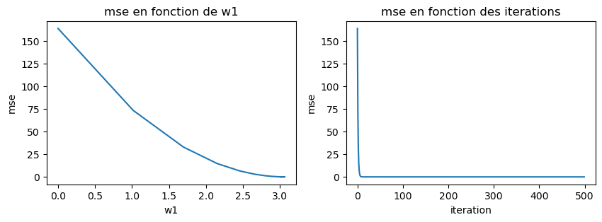

```python
def train2(X,y):
    #hyperparameters initialisation: tuning parameters
    learning_rate=0.01
    epochs=500
    #model parameters initialisation
    w1=0 #w1 attendu c'est 3
    bias=0 # attendu 1
    #----------------------
    n=len(X) #data size
    global w1List
    w1List=[] #list of w1: each iteration, we have a w1 value.
    global mseList
    mseList=[] # list of means squared errors: each iteration, we have a mse

    #training
    for i in range(epochs):
          #error calculation
        yhat=bias+w1*X #prediction
        error=y-yhat # Error
        squared_error=error**2 #squared error
        mse=(1/n)*sum(squared_error) #mean squared error
        #print("(",bias, ",", w1, ") ----->",mse)
        mseList.append(mse)
        w1List.append(w1)
        dw1=(-2/n)*np.sum(X*(y-yhat)) # partial derivate of mse / w1////0.1
        dbias=(-2/n)*np.sum((y-yhat)) #partial derivate of mse / w1

        print("iteration ",i,": (bias=",round(bias,2),",w1:",round(w1,2),") --->mse=",round(mse,5)," | update: dbias=",round(dbias,2),", dw1=",round(dw1,2))

        w1=w1-dw1*learning_rate # orientation (-) + pas d'apprentissage (l)
        bias=bias-dbias*learning_rate


    return bias,w1


#execution
bias,w1=train2(X,y)
tracer_graphes(w1List,mseList,[i for i in range(500)])
```

```python
yhat=predict(X)
print("mean squared error du modèle est:",round(mse(y,yhat),5))
```

```
mean squared error du modèle est: 0.00017
```

### questions

**1)** comment varie mse dans les 6 premières itérations? comment justifier ce résultat

**réponse** des les 6 premières itérations, mse diminue.  
à l'itération 0, mse vaut 163.6 et à l'itération 6 vaut 1.34

**2)** initiliaser w1 à la valeur 10, comment varie l'erreur? comment justifier ce résultat en se comparant à l'algorithm train1

**réponse** si on initialise w1 à 10(valeur supérieur à l'optimum w1=3), la valeur de w1 va diminuer continuellement vers la valeur 3 .  
ce résultat est justifié par le fait que la dérivée partielle dmse/dw1 permet de connaitre l'orientation de mise à jour au contraire du programme train1

**3)** Augmenter le nombre d'epochs (500 par exemple), interpréter le résultat obtenu

**réponse** si on augmente le nombre d'itération à 500, la valeur de w1 va continuer à diminuer mais avec des valeurs très petites,  
et ce est du à la dérivée qui devient tres faible une fois s'approcher du minimum d'une part, et d'autre à cause de learning_rate qui affaiblit davantage la valeur de mise à jour .

**4)** justifier la valeur de mse trouvé?

**réponse**  
pour le nombre d'epochs ègal à 10, le mse trouvé est 0.079.  
pour le nombre d'epochs ègal à 500, le mse trouvé est 0.00017.  
ce résultat est obtenu grâce aux paramètres trouvés par le programme train2.  
le règlage utilisé (combinaison de epochs et de learning_rate) a permis de touver un modèle qui donne une bonne performance

**modification de learning_rate** dans cette version de train2, learning_rate=0.1 au lieu de 0.01

```
iteration  0 : (bias= 0 ,w1: 0 ) --->mse= 163.6  | update: dbias= -22.4 , dw1= -101.6
iteration  1 : (bias= 2.24 ,w1: 10.16 ) --->mse= 871.9072  | update: dbias= 51.17 , dw1= 234.69
iteration  2 : (bias= -2.88 ,w1: -13.31 ) --->mse= 4647.40201  | update: dbias= -118.65 , dw1= -541.72
iteration  3 : (bias= 8.99 ,w1: 40.86 ) --->mse= 24771.89161  | update: dbias= 273.45 , dw1= 1250.8
iteration  4 : (bias= -18.36 ,w1: -84.22 ) --->mse= 132041.24575  | update: dbias= -631.79 , dw1= -2887.67
iteration  5 : (bias= 44.82 ,w1: 204.55 ) --->mse= 703817.90384  | update: dbias= 1458.19 , dw1= 6666.99
iteration  6 : (bias= -101.0 ,w1: -462.15 ) --->mse= 3751552.69198  | update: dbias= -3367.0 , dw1= -15392.26
iteration  7 : (bias= 235.7 ,w1: 1077.08 ) --->mse= 19996859.64191  | update: dbias= 7773.14 , dw1= 35536.84
iteration  8 : (bias= -541.61 ,w1: -2476.61 ) --->mse= 106589039.12638  | update: dbias= -17946.54 , dw1= -82045.32
iteration  9 : (bias= 1253.04 ,w1: 5727.92 ) --->mse= 568150373.14684  | update: dbias= 41433.58 , dw1= 189421.53
```

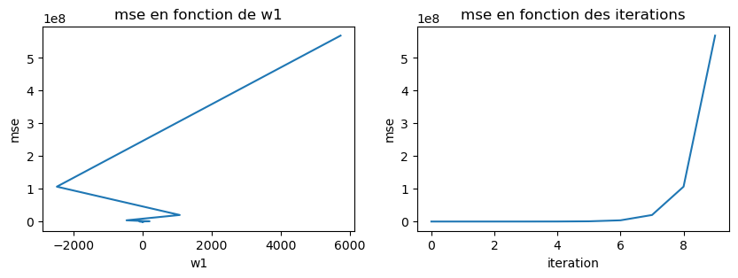

```python
def train2(X,y):
    #hyperparameters initialisation: tuning parameters
    learning_rate=0.1
    epochs=10
    #model parameters initialisation
    w1=0 #w1 attendu c'est 3
    bias=0 # attendu 1
    #----------------------
    n=len(X) #data size
    global w1List
    w1List=[] #list of w1: each iteration, we have a w1 value.
    global mseList
    mseList=[] # list of means squared errors: each iteration, we have a mse

    #training
    for i in range(epochs):
          #error calculation
        yhat=bias+w1*X #prediction
        error=y-yhat # Error
        squared_error=error**2 #squared error
        mse=(1/n)*sum(squared_error) #mean squared error
        #print("(",bias, ",", w1, ") ----->",mse)
        mseList.append(mse)
        w1List.append(w1)
        dw1=(-2/n)*np.sum(X*(y-yhat)) # partial derivate of mse / w1////0.1
        dbias=(-2/n)*np.sum((y-yhat)) #partial derivate of mse / w1
        print("iteration ",i,": (bias=",round(bias,2),",w1:",round(w1,2),") --->mse=",round(mse,5)," | update: dbias=",round(dbias,2),", dw1=",round(dw1,2))

        w1=w1-dw1*learning_rate # orientation (-) + pas d'apprentissage (l)
        bias=bias-dbias*learning_rate
    return bias,w1

#execution
bias,w1=train2(X,y)
tracer_graphes(w1List,mseList,[i for i in range(10)])
```

#### Step 2: Model Prediction

```python
def predict(x1):
    return bias+w1*x1
```

#### Step 3: Model Evaluation

vu que le dataset est tres petit, nous allons utiliser le dataset de training (X) pour évaluer le modèle (bad practice)  
pour le deuxième dataset (nuage de points: 100), nous allons utiliser une partie d'entrainement (70%) pour entrainer le modèle et une partie pour de test (30%) pour évaluer le modèle

```python
yhat=predict(X)
print("mean squared error ddu modèle est:",round(mse(y,yhat),3))
```

```
mean squared error ddu modèle est: 3028405633.249
```

### questions

**1)** comment varie mse dans les 6 premières itérations? comment justifier ce résultat

**2)** qu'est ce qui se passe si on augmente le nombre d'itération(500)?. Expliquer le résultat obtenu

### Réponses

**1)** comment varie mse dans les 6 premières itérations? comment justifier ce résultat

**Réponse**  
dans les six premières itérations,  
dans la première itération mse est 163.6 et dans l'itération 6 mse est: 3751552.69198.  
on constate que mse augmente continuellement avec de très grand pas  
en 6 itérations seulement, la valeur de mse est dèjà très grande  
ce résultat est à cause d'une mauvaise mise à jour de w1  
selon les résultats imprimés et le graphe, w1 oscille autour du minimu, mais avec des pas très grandes. et à chaque itération le pas est plus grand que le pas précédent.  
dans le programme, la dérivée partielle permet de trouver la bonne orientation, cependant, le learning_rate utilisé n'assure pas un bon pas de mise à jour (la valeur utilisée est grande contrairement à la version précédente de train2).

**2)** qu'est ce qui se passe si on augmente le nombre d'itération(500)?. Expliquer le résultat obtenu

**réponse**  
si on augmente le nombre d'epochs à 500, les valeurs de mise à jours deviennent très grandes ce qui conduit à des valeurs exponentielles de mse

### Conclusion 1

**dans la partie précédente et pour un dataset simple, nous avons vu de près les éléments suivants:**  
1- ce que c'est un modèle de régression linéaire  
2- ce que c'est un algorithme d'apprentissage  
3- ce que c'est le gradient descent  
4- le rôle des hyperparamètres: epochs et learning_rate

**dans la partie suivante, nous allons étudier un nuage de points**

### I.2. Linear Regression Model: One feature (nuage de points)

comme dans la partie précédente, dans cette partie nous allons traiter un dataset dont l'output (y) dépend d'une seule variable (x).  
le modèle à obtenir aura la forme suivante:h(x)=bias+w1.x

### I.1.1. Data

#### Step 1: Load / Initialize Data

```python
X=np.linspace(0,10,100) # générer 100 valeurs entre 0 et 10
y=2+3*X     # y à générer sur une droite bias=2, w1=3 (ideal model +/-)
 # valeurs aléatoires à ajouter à y
r=np.random.uniform(-7, 7, size=len(y))
y=y+r # update de y autour de la droite
```

#### Step 2: Plot Data

```python
#fonction qui trace :
#---1. un nuage de points
#---2. la droite sur la quelle nous nous sommes basés pour créer les y (modèle atendu)
def plot_data(X,y):
    import matplotlib.pyplot as plt
    plt.scatter(X,y,color="black")
    plt.plot(X,2+3*X,color="r") # model to find +/- (bias=2, w1=3)
    plt.show()
```

```python
#fonction qui trace :
#---1. un nuage de points
#---2. la droite sur la quelle nous nous sommes basés pour créer les y (modèle atendu)
#---3. le modèle résultat de l'apprentissage (bias,w1)

def plot_data_model(X,y,bias,w1):
    import matplotlib.pyplot as plt
    plt.scatter(X,y,color="black")
    plt.plot(X,2+3*X,color="r") # model to find +/- (bias=2, w1=3)
    plt.plot(X,bias+w1*X,color="b") #initial model (bias=1, w1=0)
    plt.show()
```

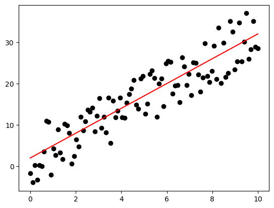

```python
plot_data(X,y)
```

#### Step 3: Split Data

#### Pourquoi?

En machine learning, toujours il faut diviser le dataset d'origine en training dataset et en testdataset afin d'évaluer la performance du modèle sur un dataset non utilisé dans la phase d'entrainement.

```python
#data(X,y)-->data_train(X_train,y_train),data_test(X_test,y_test)

X_train, X_test, y_train, y_test = train_test_split(X, y, test_size=0.3, random_state=44) #
#valeur utiliser pendant la genearation des datasets de manièere aleoire
```

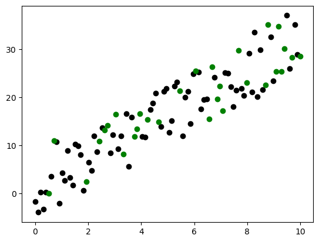

```python
plt.scatter(X_train,y_train,color="black")
plt.scatter(X_test,y_test,color="green")
```

En noir, le dataset d'entrainement.  
En vert, le dataset de test.

### I.1.2. Model (using gradient descent)

#### Step 1: Model Trainig

```
iteration  0 : (bias= 1 ,w1: 0.5 ) --->mse= 217.99  | update: dbias= -24.18 , dw1= -155.97
```

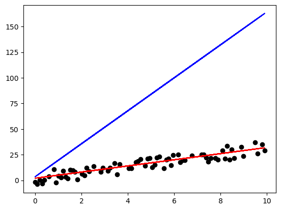

```
iteration  1 : (bias= 3.42 ,w1: 16.1 ) --->mse= 5419.84  | update: dbias= 126.32 , dw1= 807.16
```

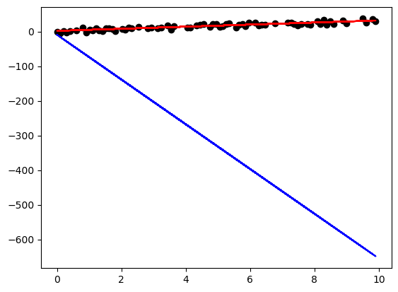

```
iteration  2 : (bias= -9.21 ,w1: -64.62 ) --->mse= 144789.15  | update: dbias= -652.75 , dw1= -4178.11
```

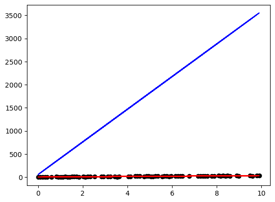

```
iteration  3 : (bias= 56.06 ,w1: 353.19 ) --->mse= 3878798.65  | update: dbias= 3379.78 , dw1= 21626.22
```

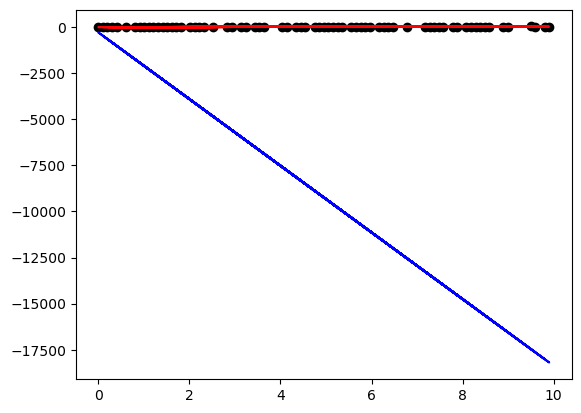

```
iteration  4 : (bias= -281.92 ,w1: -1809.43 ) --->mse= 103921102.78  | update: dbias= -17493.13 , dw1= -111940.02
```

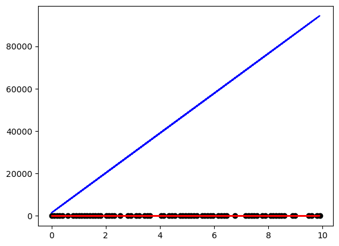

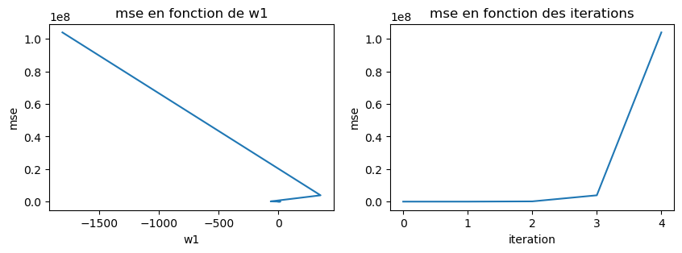

```python
def train3(X,y):
    #hyperparameters initialisation: tuning parameters
    learning_rate=0.1
    epochs=5
    #model parameters initialisation
    w1=0.5 #
    bias=1
    #----------------------
    n=len(X) #data size
    global mseList
    global w1List
    mseList=[]
    w1List=[]


    #training
    for i in range(epochs):
        yhat=bias+w1*X #prediction

        error=y-yhat # Error
        squared_error=error**2 #squared error
        mse=(1/n)*sum(squared_error) #mean squared error
        #print("(",bias, ",", w1, ") ----->",mse)
        mseList.append(mse)
        w1List.append(w1)


        dw1=(-2/n)*np.sum(X*(y-yhat)) # partial derivate of mse / w1
        dbias=(-2/n)*np.sum((y-yhat)) #partial derivate of mse / w1
        print("iteration ",i,": (bias=",round(bias,2),",w1:",round(w1,2),") --->mse=",round(mse,2)," | update: dbias=",round(dbias,2),", dw1=",round(dw1,2))

        w1=w1-dw1*learning_rate # orientation (-) + pas d'apprentissage (l)
        bias=bias-dbias*learning_rate
        plot_data_model(X,y,bias,w1)

    return bias,w1

#exécution
bias,w1=train3(X_train,y_train)
tracer_graphes(w1List,mseList,[i for i in range(5)])
```

### questions

**1)** comment varie mse dans les 5 premières itérations? comment justifier ce résultat? il s'agit de quel problème?

**2)** qu'est ce qui se passe si on augmente le nombre d'itération(500)?. Expliquer le résultat obtenu

**3)** quelles sont les recommandations à faire pour corriger ce problème

### Réponses

**1)** comment varie mse dans les 5 premières itérations? comment justifier ce résultat? il s'agit de quel problème?

**réponse**  
dans les cinq premières itérations on constate que la valeur de mse continue à augmenter au lieu de diminuer.  
vu que l'algorithme de gradient descent est implémenté correctement, alors le résultat obtenu est à cause d'un mauvais règlage: soit le nombre d'epchos ou le learning_rate  
et vu que la valeur de mse augmente des les premières itérations alors le problème concerne le learning_rate  
la valeur de learning_rate (0.1) cause un pas de mise à jour qui est grand et qui conduit à chaque itération de s'éloigner davantage de l'optimum (w1=3)

**2)** qu'est ce qui se passe si on augmente le nombre d'itération(500)?. Expliquer le résultat obtenu

**réponse**  
si on augmente le nombre d'itéraiton à 500, les mises à jour de mse deviennent exponentielles

**3)** quelles sont les recommandations à faire pour corriger ce problème

**réponse**  
Les recommandations à faire pour corriger ce problème: fixer learning_rate à une valeur plus petite à 0.1, par exemple 0.01 et voir ce qui se passe, si ce n'est pas suffissant, essayer la valeur 0.001 et ainsi de suite. il s'agit d'un problème de règlage, on peut essayer plusieurs valeurs de learning_rate jusqu'à trouver la valeur qui donne de résultat statisfaisants. pas très petits qui peut causer au programme de ne pas converger vers le bon modèle. et pas grande qui peut causer des mises à jour exponentielles

Dans la version suivante, nous allons initialisr learning_rate à 0.01 au lieu de 0.1

```
iteration  0 : (bias= 1 ,w1: 0.5 ) --->mse= 217.99  | update: dbias= -24.18 , dw1= -155.97
```

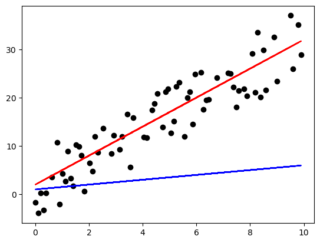

```
iteration  1 : (bias= 1.24 ,w1: 2.06 ) --->mse= 45.79  | update: dbias= -9.13 , dw1= -59.66
iteration  2 : (bias= 1.33 ,w1: 2.66 ) --->mse= 20.61  | update: dbias= -3.37 , dw1= -22.83
iteration  3 : (bias= 1.37 ,w1: 2.88 ) --->mse= 16.93  | update: dbias= -1.17 , dw1= -8.75
iteration  4 : (bias= 1.38 ,w1: 2.97 ) --->mse= 16.39  | update: dbias= -0.33 , dw1= -3.36
iteration  5 : (bias= 1.38 ,w1: 3.01 ) --->mse= 16.31  | update: dbias= -0.01 , dw1= -1.3
iteration  6 : (bias= 1.38 ,w1: 3.02 ) --->mse= 16.3  | update: dbias= 0.11 , dw1= -0.52
iteration  7 : (bias= 1.38 ,w1: 3.02 ) --->mse= 16.3  | update: dbias= 0.16 , dw1= -0.22
iteration  8 : (bias= 1.38 ,w1: 3.03 ) --->mse= 16.3  | update: dbias= 0.17 , dw1= -0.1
iteration  9 : (bias= 1.38 ,w1: 3.03 ) --->mse= 16.3  | update: dbias= 0.18 , dw1= -0.06
iteration  10 : (bias= 1.38 ,w1: 3.03 ) --->mse= 16.3  | update: dbias= 0.18 , dw1= -0.04
iteration  11 : (bias= 1.37 ,w1: 3.03 ) --->mse= 16.3  | update: dbias= 0.18 , dw1= -0.03
iteration  12 : (bias= 1.37 ,w1: 3.03 ) --->mse= 16.3  | update: dbias= 0.18 , dw1= -0.03
iteration  13 : (bias= 1.37 ,w1: 3.03 ) --->mse= 16.3  | update: dbias= 0.18 , dw1= -0.03
iteration  14 : (bias= 1.37 ,w1: 3.03 ) --->mse= 16.3  | update: dbias= 0.18 , dw1= -0.03
iteration  15 : (bias= 1.37 ,w1: 3.03 ) --->mse= 16.3  | update: dbias= 0.18 , dw1= -0.03
iteration  16 : (bias= 1.37 ,w1: 3.03 ) --->mse= 16.3  | update: dbias= 0.18 , dw1= -0.03
iteration  17 : (bias= 1.36 ,w1: 3.03 ) --->mse= 16.3  | update: dbias= 0.17 , dw1= -0.03
iteration  18 : (bias= 1.36 ,w1: 3.03 ) --->mse= 16.3  | update: dbias= 0.17 , dw1= -0.03
iteration  19 : (bias= 1.36 ,w1: 3.03 ) --->mse= 16.3  | update: dbias= 0.17 , dw1= -0.03
iteration  20 : (bias= 1.36 ,w1: 3.03 ) --->mse= 16.29  | update: dbias= 0.17 , dw1= -0.03
iteration  21 : (bias= 1.36 ,w1: 3.03 ) --->mse= 16.29  | update: dbias= 0.17 , dw1= -0.03
iteration  22 : (bias= 1.35 ,w1: 3.03 ) --->mse= 16.29  | update: dbias= 0.17 , dw1= -0.03
iteration  23 : (bias= 1.35 ,w1: 3.03 ) --->mse= 16.29  | update: dbias= 0.17 , dw1= -0.03
iteration  24 : (bias= 1.35 ,w1: 3.03 ) --->mse= 16.29  | update: dbias= 0.17 , dw1= -0.03
iteration  25 : (bias= 1.35 ,w1: 3.03 ) --->mse= 16.29  | update: dbias= 0.17 , dw1= -0.03
iteration  26 : (bias= 1.35 ,w1: 3.03 ) --->mse= 16.29  | update: dbias= 0.17 , dw1= -0.03
iteration  27 : (bias= 1.35 ,w1: 3.03 ) --->mse= 16.29  | update: dbias= 0.17 , dw1= -0.03
iteration  28 : (bias= 1.34 ,w1: 3.03 ) --->mse= 16.29  | update: dbias= 0.16 , dw1= -0.03
iteration  29 : (bias= 1.34 ,w1: 3.03 ) --->mse= 16.29  | update: dbias= 0.16 , dw1= -0.03
iteration  30 : (bias= 1.34 ,w1: 3.03 ) --->mse= 16.29  | update: dbias= 0.16 , dw1= -0.03
iteration  31 : (bias= 1.34 ,w1: 3.03 ) --->mse= 16.29  | update: dbias= 0.16 , dw1= -0.03
iteration  32 : (bias= 1.34 ,w1: 3.03 ) --->mse= 16.29  | update: dbias= 0.16 , dw1= -0.03
iteration  33 : (bias= 1.34 ,w1: 3.03 ) --->mse= 16.29  | update: dbias= 0.16 , dw1= -0.03
iteration  34 : (bias= 1.33 ,w1: 3.03 ) --->mse= 16.29  | update: dbias= 0.16 , dw1= -0.02
iteration  35 : (bias= 1.33 ,w1: 3.03 ) --->mse= 16.29  | update: dbias= 0.16 , dw1= -0.02
iteration  36 : (bias= 1.33 ,w1: 3.03 ) --->mse= 16.29  | update: dbias= 0.16 , dw1= -0.02
iteration  37 : (bias= 1.33 ,w1: 3.04 ) --->mse= 16.29  | update: dbias= 0.16 , dw1= -0.02
iteration  38 : (bias= 1.33 ,w1: 3.04 ) --->mse= 16.29  | update: dbias= 0.16 , dw1= -0.02
iteration  39 : (bias= 1.33 ,w1: 3.04 ) --->mse= 16.29  | update: dbias= 0.15 , dw1= -0.02
iteration  40 : (bias= 1.33 ,w1: 3.04 ) --->mse= 16.29  | update: dbias= 0.15 , dw1= -0.02
```

[output cut: 45 more lines]

```
iteration  86 : (bias= 1.26 ,w1: 3.05 ) --->mse= 16.28  | update: dbias= 0.12 , dw1= -0.02
iteration  87 : (bias= 1.26 ,w1: 3.05 ) --->mse= 16.28  | update: dbias= 0.12 , dw1= -0.02
iteration  88 : (bias= 1.26 ,w1: 3.05 ) --->mse= 16.28  | update: dbias= 0.12 , dw1= -0.02
iteration  89 : (bias= 1.26 ,w1: 3.05 ) --->mse= 16.28  | update: dbias= 0.12 , dw1= -0.02
iteration  90 : (bias= 1.26 ,w1: 3.05 ) --->mse= 16.28  | update: dbias= 0.12 , dw1= -0.02
iteration  91 : (bias= 1.26 ,w1: 3.05 ) --->mse= 16.28  | update: dbias= 0.12 , dw1= -0.02
iteration  92 : (bias= 1.26 ,w1: 3.05 ) --->mse= 16.28  | update: dbias= 0.12 , dw1= -0.02
iteration  93 : (bias= 1.25 ,w1: 3.05 ) --->mse= 16.28  | update: dbias= 0.12 , dw1= -0.02
iteration  94 : (bias= 1.25 ,w1: 3.05 ) --->mse= 16.28  | update: dbias= 0.12 , dw1= -0.02
iteration  95 : (bias= 1.25 ,w1: 3.05 ) --->mse= 16.28  | update: dbias= 0.11 , dw1= -0.02
iteration  96 : (bias= 1.25 ,w1: 3.05 ) --->mse= 16.28  | update: dbias= 0.11 , dw1= -0.02
iteration  97 : (bias= 1.25 ,w1: 3.05 ) --->mse= 16.28  | update: dbias= 0.11 , dw1= -0.02
iteration  98 : (bias= 1.25 ,w1: 3.05 ) --->mse= 16.28  | update: dbias= 0.11 , dw1= -0.02
iteration  99 : (bias= 1.25 ,w1: 3.05 ) --->mse= 16.28  | update: dbias= 0.11 , dw1= -0.02
iteration  100 : (bias= 1.25 ,w1: 3.05 ) --->mse= 16.28  | update: dbias= 0.11 , dw1= -0.02
```

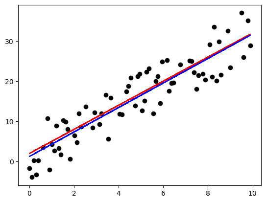

```
iteration  101 : (bias= 1.25 ,w1: 3.05 ) --->mse= 16.28  | update: dbias= 0.11 , dw1= -0.02
iteration  102 : (bias= 1.24 ,w1: 3.05 ) --->mse= 16.28  | update: dbias= 0.11 , dw1= -0.02
iteration  103 : (bias= 1.24 ,w1: 3.05 ) --->mse= 16.28  | update: dbias= 0.11 , dw1= -0.02
iteration  104 : (bias= 1.24 ,w1: 3.05 ) --->mse= 16.28  | update: dbias= 0.11 , dw1= -0.02
iteration  105 : (bias= 1.24 ,w1: 3.05 ) --->mse= 16.28  | update: dbias= 0.11 , dw1= -0.02
iteration  106 : (bias= 1.24 ,w1: 3.05 ) --->mse= 16.28  | update: dbias= 0.11 , dw1= -0.02
iteration  107 : (bias= 1.24 ,w1: 3.05 ) --->mse= 16.28  | update: dbias= 0.11 , dw1= -0.02
iteration  108 : (bias= 1.24 ,w1: 3.05 ) --->mse= 16.28  | update: dbias= 0.11 , dw1= -0.02
iteration  109 : (bias= 1.24 ,w1: 3.05 ) --->mse= 16.28  | update: dbias= 0.11 , dw1= -0.02
iteration  110 : (bias= 1.24 ,w1: 3.05 ) --->mse= 16.28  | update: dbias= 0.11 , dw1= -0.02
iteration  111 : (bias= 1.23 ,w1: 3.05 ) --->mse= 16.28  | update: dbias= 0.1 , dw1= -0.02
iteration  112 : (bias= 1.23 ,w1: 3.05 ) --->mse= 16.28  | update: dbias= 0.1 , dw1= -0.02
iteration  113 : (bias= 1.23 ,w1: 3.05 ) --->mse= 16.28  | update: dbias= 0.1 , dw1= -0.02
iteration  114 : (bias= 1.23 ,w1: 3.05 ) --->mse= 16.28  | update: dbias= 0.1 , dw1= -0.02
iteration  115 : (bias= 1.23 ,w1: 3.05 ) --->mse= 16.28  | update: dbias= 0.1 , dw1= -0.02
iteration  116 : (bias= 1.23 ,w1: 3.05 ) --->mse= 16.28  | update: dbias= 0.1 , dw1= -0.02
iteration  117 : (bias= 1.23 ,w1: 3.05 ) --->mse= 16.28  | update: dbias= 0.1 , dw1= -0.02
iteration  118 : (bias= 1.23 ,w1: 3.05 ) --->mse= 16.28  | update: dbias= 0.1 , dw1= -0.02
iteration  119 : (bias= 1.23 ,w1: 3.05 ) --->mse= 16.28  | update: dbias= 0.1 , dw1= -0.02
iteration  120 : (bias= 1.23 ,w1: 3.05 ) --->mse= 16.28  | update: dbias= 0.1 , dw1= -0.02
iteration  121 : (bias= 1.22 ,w1: 3.05 ) --->mse= 16.28  | update: dbias= 0.1 , dw1= -0.02
iteration  122 : (bias= 1.22 ,w1: 3.05 ) --->mse= 16.28  | update: dbias= 0.1 , dw1= -0.02
iteration  123 : (bias= 1.22 ,w1: 3.05 ) --->mse= 16.28  | update: dbias= 0.1 , dw1= -0.02
iteration  124 : (bias= 1.22 ,w1: 3.05 ) --->mse= 16.28  | update: dbias= 0.1 , dw1= -0.02
iteration  125 : (bias= 1.22 ,w1: 3.05 ) --->mse= 16.28  | update: dbias= 0.1 , dw1= -0.02
iteration  126 : (bias= 1.22 ,w1: 3.05 ) --->mse= 16.28  | update: dbias= 0.1 , dw1= -0.02
iteration  127 : (bias= 1.22 ,w1: 3.05 ) --->mse= 16.28  | update: dbias= 0.1 , dw1= -0.02
iteration  128 : (bias= 1.22 ,w1: 3.05 ) --->mse= 16.28  | update: dbias= 0.1 , dw1= -0.01
iteration  129 : (bias= 1.22 ,w1: 3.05 ) --->mse= 16.28  | update: dbias= 0.1 , dw1= -0.01
iteration  130 : (bias= 1.22 ,w1: 3.05 ) --->mse= 16.28  | update: dbias= 0.09 , dw1= -0.01
iteration  131 : (bias= 1.21 ,w1: 3.05 ) --->mse= 16.28  | update: dbias= 0.09 , dw1= -0.01
iteration  132 : (bias= 1.21 ,w1: 3.05 ) --->mse= 16.28  | update: dbias= 0.09 , dw1= -0.01
iteration  133 : (bias= 1.21 ,w1: 3.05 ) --->mse= 16.28  | update: dbias= 0.09 , dw1= -0.01
iteration  134 : (bias= 1.21 ,w1: 3.05 ) --->mse= 16.28  | update: dbias= 0.09 , dw1= -0.01
iteration  135 : (bias= 1.21 ,w1: 3.05 ) --->mse= 16.27  | update: dbias= 0.09 , dw1= -0.01
iteration  136 : (bias= 1.21 ,w1: 3.05 ) --->mse= 16.27  | update: dbias= 0.09 , dw1= -0.01
iteration  137 : (bias= 1.21 ,w1: 3.05 ) --->mse= 16.27  | update: dbias= 0.09 , dw1= -0.01
iteration  138 : (bias= 1.21 ,w1: 3.05 ) --->mse= 16.27  | update: dbias= 0.09 , dw1= -0.01
iteration  139 : (bias= 1.21 ,w1: 3.05 ) --->mse= 16.27  | update: dbias= 0.09 , dw1= -0.01
iteration  140 : (bias= 1.21 ,w1: 3.05 ) --->mse= 16.27  | update: dbias= 0.09 , dw1= -0.01
```

[output cut: 45 more lines]

```
iteration  186 : (bias= 1.17 ,w1: 3.06 ) --->mse= 16.27  | update: dbias= 0.07 , dw1= -0.01
iteration  187 : (bias= 1.17 ,w1: 3.06 ) --->mse= 16.27  | update: dbias= 0.07 , dw1= -0.01
iteration  188 : (bias= 1.17 ,w1: 3.06 ) --->mse= 16.27  | update: dbias= 0.07 , dw1= -0.01
iteration  189 : (bias= 1.17 ,w1: 3.06 ) --->mse= 16.27  | update: dbias= 0.07 , dw1= -0.01
iteration  190 : (bias= 1.17 ,w1: 3.06 ) --->mse= 16.27  | update: dbias= 0.07 , dw1= -0.01
iteration  191 : (bias= 1.17 ,w1: 3.06 ) --->mse= 16.27  | update: dbias= 0.07 , dw1= -0.01
iteration  192 : (bias= 1.17 ,w1: 3.06 ) --->mse= 16.27  | update: dbias= 0.07 , dw1= -0.01
iteration  193 : (bias= 1.16 ,w1: 3.06 ) --->mse= 16.27  | update: dbias= 0.07 , dw1= -0.01
iteration  194 : (bias= 1.16 ,w1: 3.06 ) --->mse= 16.27  | update: dbias= 0.07 , dw1= -0.01
iteration  195 : (bias= 1.16 ,w1: 3.06 ) --->mse= 16.27  | update: dbias= 0.07 , dw1= -0.01
iteration  196 : (bias= 1.16 ,w1: 3.06 ) --->mse= 16.27  | update: dbias= 0.07 , dw1= -0.01
iteration  197 : (bias= 1.16 ,w1: 3.06 ) --->mse= 16.27  | update: dbias= 0.07 , dw1= -0.01
iteration  198 : (bias= 1.16 ,w1: 3.06 ) --->mse= 16.27  | update: dbias= 0.07 , dw1= -0.01
iteration  199 : (bias= 1.16 ,w1: 3.06 ) --->mse= 16.27  | update: dbias= 0.07 , dw1= -0.01
iteration  200 : (bias= 1.16 ,w1: 3.06 ) --->mse= 16.27  | update: dbias= 0.06 , dw1= -0.01
```

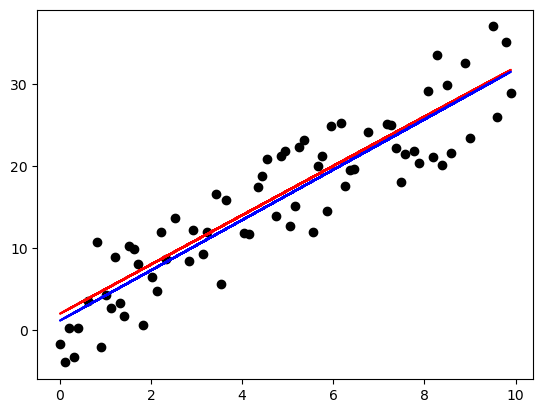

```
iteration  201 : (bias= 1.16 ,w1: 3.06 ) --->mse= 16.27  | update: dbias= 0.06 , dw1= -0.01
iteration  202 : (bias= 1.16 ,w1: 3.06 ) --->mse= 16.27  | update: dbias= 0.06 , dw1= -0.01
iteration  203 : (bias= 1.16 ,w1: 3.06 ) --->mse= 16.27  | update: dbias= 0.06 , dw1= -0.01
iteration  204 : (bias= 1.16 ,w1: 3.06 ) --->mse= 16.27  | update: dbias= 0.06 , dw1= -0.01
iteration  205 : (bias= 1.16 ,w1: 3.06 ) --->mse= 16.27  | update: dbias= 0.06 , dw1= -0.01
iteration  206 : (bias= 1.16 ,w1: 3.06 ) --->mse= 16.27  | update: dbias= 0.06 , dw1= -0.01
iteration  207 : (bias= 1.16 ,w1: 3.06 ) --->mse= 16.27  | update: dbias= 0.06 , dw1= -0.01
iteration  208 : (bias= 1.16 ,w1: 3.06 ) --->mse= 16.27  | update: dbias= 0.06 , dw1= -0.01
iteration  209 : (bias= 1.15 ,w1: 3.06 ) --->mse= 16.27  | update: dbias= 0.06 , dw1= -0.01
iteration  210 : (bias= 1.15 ,w1: 3.06 ) --->mse= 16.27  | update: dbias= 0.06 , dw1= -0.01
iteration  211 : (bias= 1.15 ,w1: 3.06 ) --->mse= 16.27  | update: dbias= 0.06 , dw1= -0.01
iteration  212 : (bias= 1.15 ,w1: 3.06 ) --->mse= 16.27  | update: dbias= 0.06 , dw1= -0.01
iteration  213 : (bias= 1.15 ,w1: 3.06 ) --->mse= 16.27  | update: dbias= 0.06 , dw1= -0.01
iteration  214 : (bias= 1.15 ,w1: 3.06 ) --->mse= 16.27  | update: dbias= 0.06 , dw1= -0.01
iteration  215 : (bias= 1.15 ,w1: 3.06 ) --->mse= 16.27  | update: dbias= 0.06 , dw1= -0.01
iteration  216 : (bias= 1.15 ,w1: 3.06 ) --->mse= 16.27  | update: dbias= 0.06 , dw1= -0.01
iteration  217 : (bias= 1.15 ,w1: 3.06 ) --->mse= 16.27  | update: dbias= 0.06 , dw1= -0.01
iteration  218 : (bias= 1.15 ,w1: 3.06 ) --->mse= 16.27  | update: dbias= 0.06 , dw1= -0.01
iteration  219 : (bias= 1.15 ,w1: 3.06 ) --->mse= 16.27  | update: dbias= 0.06 , dw1= -0.01
iteration  220 : (bias= 1.15 ,w1: 3.06 ) --->mse= 16.27  | update: dbias= 0.06 , dw1= -0.01
iteration  221 : (bias= 1.15 ,w1: 3.06 ) --->mse= 16.27  | update: dbias= 0.06 , dw1= -0.01
iteration  222 : (bias= 1.15 ,w1: 3.06 ) --->mse= 16.27  | update: dbias= 0.06 , dw1= -0.01
iteration  223 : (bias= 1.15 ,w1: 3.06 ) --->mse= 16.27  | update: dbias= 0.06 , dw1= -0.01
iteration  224 : (bias= 1.15 ,w1: 3.06 ) --->mse= 16.27  | update: dbias= 0.06 , dw1= -0.01
iteration  225 : (bias= 1.15 ,w1: 3.06 ) --->mse= 16.27  | update: dbias= 0.06 , dw1= -0.01
iteration  226 : (bias= 1.14 ,w1: 3.06 ) --->mse= 16.27  | update: dbias= 0.06 , dw1= -0.01
iteration  227 : (bias= 1.14 ,w1: 3.06 ) --->mse= 16.27  | update: dbias= 0.06 , dw1= -0.01
iteration  228 : (bias= 1.14 ,w1: 3.06 ) --->mse= 16.27  | update: dbias= 0.06 , dw1= -0.01
iteration  229 : (bias= 1.14 ,w1: 3.06 ) --->mse= 16.27  | update: dbias= 0.06 , dw1= -0.01
iteration  230 : (bias= 1.14 ,w1: 3.06 ) --->mse= 16.27  | update: dbias= 0.06 , dw1= -0.01
iteration  231 : (bias= 1.14 ,w1: 3.06 ) --->mse= 16.27  | update: dbias= 0.05 , dw1= -0.01
iteration  232 : (bias= 1.14 ,w1: 3.06 ) --->mse= 16.27  | update: dbias= 0.05 , dw1= -0.01
iteration  233 : (bias= 1.14 ,w1: 3.06 ) --->mse= 16.27  | update: dbias= 0.05 , dw1= -0.01
iteration  234 : (bias= 1.14 ,w1: 3.06 ) --->mse= 16.27  | update: dbias= 0.05 , dw1= -0.01
iteration  235 : (bias= 1.14 ,w1: 3.06 ) --->mse= 16.27  | update: dbias= 0.05 , dw1= -0.01
iteration  236 : (bias= 1.14 ,w1: 3.06 ) --->mse= 16.27  | update: dbias= 0.05 , dw1= -0.01
iteration  237 : (bias= 1.14 ,w1: 3.06 ) --->mse= 16.27  | update: dbias= 0.05 , dw1= -0.01
iteration  238 : (bias= 1.14 ,w1: 3.07 ) --->mse= 16.27  | update: dbias= 0.05 , dw1= -0.01
iteration  239 : (bias= 1.14 ,w1: 3.07 ) --->mse= 16.27  | update: dbias= 0.05 , dw1= -0.01
iteration  240 : (bias= 1.14 ,w1: 3.07 ) --->mse= 16.27  | update: dbias= 0.05 , dw1= -0.01
```

[output cut: 45 more lines]

```
iteration  286 : (bias= 1.12 ,w1: 3.07 ) --->mse= 16.27  | update: dbias= 0.04 , dw1= -0.01
iteration  287 : (bias= 1.12 ,w1: 3.07 ) --->mse= 16.27  | update: dbias= 0.04 , dw1= -0.01
iteration  288 : (bias= 1.11 ,w1: 3.07 ) --->mse= 16.27  | update: dbias= 0.04 , dw1= -0.01
iteration  289 : (bias= 1.11 ,w1: 3.07 ) --->mse= 16.27  | update: dbias= 0.04 , dw1= -0.01
iteration  290 : (bias= 1.11 ,w1: 3.07 ) --->mse= 16.27  | update: dbias= 0.04 , dw1= -0.01
iteration  291 : (bias= 1.11 ,w1: 3.07 ) --->mse= 16.27  | update: dbias= 0.04 , dw1= -0.01
iteration  292 : (bias= 1.11 ,w1: 3.07 ) --->mse= 16.27  | update: dbias= 0.04 , dw1= -0.01
iteration  293 : (bias= 1.11 ,w1: 3.07 ) --->mse= 16.27  | update: dbias= 0.04 , dw1= -0.01
iteration  294 : (bias= 1.11 ,w1: 3.07 ) --->mse= 16.27  | update: dbias= 0.04 , dw1= -0.01
iteration  295 : (bias= 1.11 ,w1: 3.07 ) --->mse= 16.27  | update: dbias= 0.04 , dw1= -0.01
iteration  296 : (bias= 1.11 ,w1: 3.07 ) --->mse= 16.27  | update: dbias= 0.04 , dw1= -0.01
iteration  297 : (bias= 1.11 ,w1: 3.07 ) --->mse= 16.27  | update: dbias= 0.04 , dw1= -0.01
iteration  298 : (bias= 1.11 ,w1: 3.07 ) --->mse= 16.27  | update: dbias= 0.04 , dw1= -0.01
iteration  299 : (bias= 1.11 ,w1: 3.07 ) --->mse= 16.27  | update: dbias= 0.04 , dw1= -0.01
iteration  300 : (bias= 1.11 ,w1: 3.07 ) --->mse= 16.27  | update: dbias= 0.04 , dw1= -0.01
```

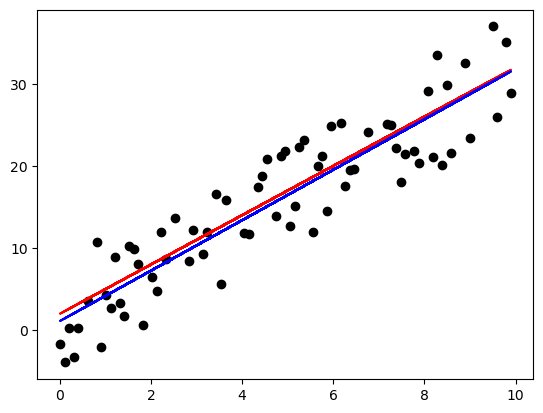

```
iteration  301 : (bias= 1.11 ,w1: 3.07 ) --->mse= 16.27  | update: dbias= 0.04 , dw1= -0.01
iteration  302 : (bias= 1.11 ,w1: 3.07 ) --->mse= 16.27  | update: dbias= 0.04 , dw1= -0.01
iteration  303 : (bias= 1.11 ,w1: 3.07 ) --->mse= 16.27  | update: dbias= 0.04 , dw1= -0.01
iteration  304 : (bias= 1.11 ,w1: 3.07 ) --->mse= 16.27  | update: dbias= 0.04 , dw1= -0.01
iteration  305 : (bias= 1.11 ,w1: 3.07 ) --->mse= 16.27  | update: dbias= 0.04 , dw1= -0.01
iteration  306 : (bias= 1.11 ,w1: 3.07 ) --->mse= 16.27  | update: dbias= 0.04 , dw1= -0.01
iteration  307 : (bias= 1.11 ,w1: 3.07 ) --->mse= 16.27  | update: dbias= 0.04 , dw1= -0.01
iteration  308 : (bias= 1.11 ,w1: 3.07 ) --->mse= 16.27  | update: dbias= 0.04 , dw1= -0.01
iteration  309 : (bias= 1.11 ,w1: 3.07 ) --->mse= 16.27  | update: dbias= 0.04 , dw1= -0.01
iteration  310 : (bias= 1.11 ,w1: 3.07 ) --->mse= 16.27  | update: dbias= 0.04 , dw1= -0.01
iteration  311 : (bias= 1.11 ,w1: 3.07 ) --->mse= 16.27  | update: dbias= 0.04 , dw1= -0.01
iteration  312 : (bias= 1.11 ,w1: 3.07 ) --->mse= 16.27  | update: dbias= 0.04 , dw1= -0.01
iteration  313 : (bias= 1.11 ,w1: 3.07 ) --->mse= 16.27  | update: dbias= 0.04 , dw1= -0.01
iteration  314 : (bias= 1.1 ,w1: 3.07 ) --->mse= 16.27  | update: dbias= 0.03 , dw1= -0.01
iteration  315 : (bias= 1.1 ,w1: 3.07 ) --->mse= 16.27  | update: dbias= 0.03 , dw1= -0.01
iteration  316 : (bias= 1.1 ,w1: 3.07 ) --->mse= 16.27  | update: dbias= 0.03 , dw1= -0.01
iteration  317 : (bias= 1.1 ,w1: 3.07 ) --->mse= 16.27  | update: dbias= 0.03 , dw1= -0.01
iteration  318 : (bias= 1.1 ,w1: 3.07 ) --->mse= 16.27  | update: dbias= 0.03 , dw1= -0.01
iteration  319 : (bias= 1.1 ,w1: 3.07 ) --->mse= 16.27  | update: dbias= 0.03 , dw1= -0.01
iteration  320 : (bias= 1.1 ,w1: 3.07 ) --->mse= 16.27  | update: dbias= 0.03 , dw1= -0.01
iteration  321 : (bias= 1.1 ,w1: 3.07 ) --->mse= 16.27  | update: dbias= 0.03 , dw1= -0.01
iteration  322 : (bias= 1.1 ,w1: 3.07 ) --->mse= 16.27  | update: dbias= 0.03 , dw1= -0.01
iteration  323 : (bias= 1.1 ,w1: 3.07 ) --->mse= 16.27  | update: dbias= 0.03 , dw1= -0.01
iteration  324 : (bias= 1.1 ,w1: 3.07 ) --->mse= 16.27  | update: dbias= 0.03 , dw1= -0.01
iteration  325 : (bias= 1.1 ,w1: 3.07 ) --->mse= 16.27  | update: dbias= 0.03 , dw1= -0.01
iteration  326 : (bias= 1.1 ,w1: 3.07 ) --->mse= 16.27  | update: dbias= 0.03 , dw1= -0.01
iteration  327 : (bias= 1.1 ,w1: 3.07 ) --->mse= 16.27  | update: dbias= 0.03 , dw1= -0.01
iteration  328 : (bias= 1.1 ,w1: 3.07 ) --->mse= 16.27  | update: dbias= 0.03 , dw1= -0.01
iteration  329 : (bias= 1.1 ,w1: 3.07 ) --->mse= 16.27  | update: dbias= 0.03 , dw1= -0.01
iteration  330 : (bias= 1.1 ,w1: 3.07 ) --->mse= 16.27  | update: dbias= 0.03 , dw1= -0.01
iteration  331 : (bias= 1.1 ,w1: 3.07 ) --->mse= 16.27  | update: dbias= 0.03 , dw1= -0.0
iteration  332 : (bias= 1.1 ,w1: 3.07 ) --->mse= 16.27  | update: dbias= 0.03 , dw1= -0.0
iteration  333 : (bias= 1.1 ,w1: 3.07 ) --->mse= 16.27  | update: dbias= 0.03 , dw1= -0.0
iteration  334 : (bias= 1.1 ,w1: 3.07 ) --->mse= 16.27  | update: dbias= 0.03 , dw1= -0.0
iteration  335 : (bias= 1.1 ,w1: 3.07 ) --->mse= 16.27  | update: dbias= 0.03 , dw1= -0.0
iteration  336 : (bias= 1.1 ,w1: 3.07 ) --->mse= 16.27  | update: dbias= 0.03 , dw1= -0.0
iteration  337 : (bias= 1.1 ,w1: 3.07 ) --->mse= 16.27  | update: dbias= 0.03 , dw1= -0.0
iteration  338 : (bias= 1.1 ,w1: 3.07 ) --->mse= 16.27  | update: dbias= 0.03 , dw1= -0.0
iteration  339 : (bias= 1.1 ,w1: 3.07 ) --->mse= 16.27  | update: dbias= 0.03 , dw1= -0.0
iteration  340 : (bias= 1.1 ,w1: 3.07 ) --->mse= 16.27  | update: dbias= 0.03 , dw1= -0.0
```

[output cut: 45 more lines]

```
iteration  386 : (bias= 1.08 ,w1: 3.07 ) --->mse= 16.27  | update: dbias= 0.02 , dw1= -0.0
iteration  387 : (bias= 1.08 ,w1: 3.07 ) --->mse= 16.27  | update: dbias= 0.02 , dw1= -0.0
iteration  388 : (bias= 1.08 ,w1: 3.07 ) --->mse= 16.27  | update: dbias= 0.02 , dw1= -0.0
iteration  389 : (bias= 1.08 ,w1: 3.07 ) --->mse= 16.27  | update: dbias= 0.02 , dw1= -0.0
iteration  390 : (bias= 1.08 ,w1: 3.07 ) --->mse= 16.27  | update: dbias= 0.02 , dw1= -0.0
iteration  391 : (bias= 1.08 ,w1: 3.07 ) --->mse= 16.27  | update: dbias= 0.02 , dw1= -0.0
iteration  392 : (bias= 1.08 ,w1: 3.07 ) --->mse= 16.27  | update: dbias= 0.02 , dw1= -0.0
iteration  393 : (bias= 1.08 ,w1: 3.07 ) --->mse= 16.27  | update: dbias= 0.02 , dw1= -0.0
iteration  394 : (bias= 1.08 ,w1: 3.07 ) --->mse= 16.27  | update: dbias= 0.02 , dw1= -0.0
iteration  395 : (bias= 1.08 ,w1: 3.07 ) --->mse= 16.27  | update: dbias= 0.02 , dw1= -0.0
iteration  396 : (bias= 1.08 ,w1: 3.07 ) --->mse= 16.27  | update: dbias= 0.02 , dw1= -0.0
iteration  397 : (bias= 1.08 ,w1: 3.07 ) --->mse= 16.27  | update: dbias= 0.02 , dw1= -0.0
iteration  398 : (bias= 1.08 ,w1: 3.07 ) --->mse= 16.27  | update: dbias= 0.02 , dw1= -0.0
iteration  399 : (bias= 1.08 ,w1: 3.07 ) --->mse= 16.27  | update: dbias= 0.02 , dw1= -0.0
iteration  400 : (bias= 1.08 ,w1: 3.07 ) --->mse= 16.27  | update: dbias= 0.02 , dw1= -0.0
```

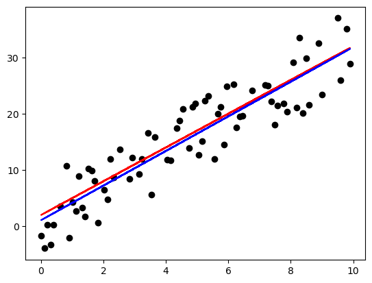

```
iteration  401 : (bias= 1.08 ,w1: 3.07 ) --->mse= 16.27  | update: dbias= 0.02 , dw1= -0.0
iteration  402 : (bias= 1.08 ,w1: 3.07 ) --->mse= 16.27  | update: dbias= 0.02 , dw1= -0.0
iteration  403 : (bias= 1.08 ,w1: 3.07 ) --->mse= 16.27  | update: dbias= 0.02 , dw1= -0.0
iteration  404 : (bias= 1.08 ,w1: 3.07 ) --->mse= 16.27  | update: dbias= 0.02 , dw1= -0.0
iteration  405 : (bias= 1.08 ,w1: 3.07 ) --->mse= 16.27  | update: dbias= 0.02 , dw1= -0.0
iteration  406 : (bias= 1.08 ,w1: 3.07 ) --->mse= 16.27  | update: dbias= 0.02 , dw1= -0.0
iteration  407 : (bias= 1.08 ,w1: 3.07 ) --->mse= 16.27  | update: dbias= 0.02 , dw1= -0.0
iteration  408 : (bias= 1.08 ,w1: 3.07 ) --->mse= 16.27  | update: dbias= 0.02 , dw1= -0.0
iteration  409 : (bias= 1.08 ,w1: 3.07 ) --->mse= 16.27  | update: dbias= 0.02 , dw1= -0.0
iteration  410 : (bias= 1.08 ,w1: 3.07 ) --->mse= 16.27  | update: dbias= 0.02 , dw1= -0.0
iteration  411 : (bias= 1.08 ,w1: 3.07 ) --->mse= 16.27  | update: dbias= 0.02 , dw1= -0.0
iteration  412 : (bias= 1.08 ,w1: 3.07 ) --->mse= 16.27  | update: dbias= 0.02 , dw1= -0.0
iteration  413 : (bias= 1.08 ,w1: 3.07 ) --->mse= 16.27  | update: dbias= 0.02 , dw1= -0.0
iteration  414 : (bias= 1.08 ,w1: 3.07 ) --->mse= 16.27  | update: dbias= 0.02 , dw1= -0.0
iteration  415 : (bias= 1.08 ,w1: 3.07 ) --->mse= 16.27  | update: dbias= 0.02 , dw1= -0.0
iteration  416 : (bias= 1.08 ,w1: 3.07 ) --->mse= 16.27  | update: dbias= 0.02 , dw1= -0.0
iteration  417 : (bias= 1.08 ,w1: 3.07 ) --->mse= 16.27  | update: dbias= 0.02 , dw1= -0.0
iteration  418 : (bias= 1.08 ,w1: 3.07 ) --->mse= 16.27  | update: dbias= 0.02 , dw1= -0.0
iteration  419 : (bias= 1.08 ,w1: 3.07 ) --->mse= 16.27  | update: dbias= 0.02 , dw1= -0.0
iteration  420 : (bias= 1.08 ,w1: 3.07 ) --->mse= 16.27  | update: dbias= 0.02 , dw1= -0.0
iteration  421 : (bias= 1.08 ,w1: 3.07 ) --->mse= 16.27  | update: dbias= 0.02 , dw1= -0.0
iteration  422 : (bias= 1.08 ,w1: 3.07 ) --->mse= 16.27  | update: dbias= 0.02 , dw1= -0.0
iteration  423 : (bias= 1.08 ,w1: 3.07 ) --->mse= 16.27  | update: dbias= 0.02 , dw1= -0.0
iteration  424 : (bias= 1.08 ,w1: 3.07 ) --->mse= 16.27  | update: dbias= 0.02 , dw1= -0.0
iteration  425 : (bias= 1.08 ,w1: 3.07 ) --->mse= 16.27  | update: dbias= 0.02 , dw1= -0.0
iteration  426 : (bias= 1.08 ,w1: 3.07 ) --->mse= 16.27  | update: dbias= 0.02 , dw1= -0.0
iteration  427 : (bias= 1.08 ,w1: 3.07 ) --->mse= 16.27  | update: dbias= 0.02 , dw1= -0.0
iteration  428 : (bias= 1.08 ,w1: 3.07 ) --->mse= 16.27  | update: dbias= 0.02 , dw1= -0.0
iteration  429 : (bias= 1.08 ,w1: 3.07 ) --->mse= 16.27  | update: dbias= 0.02 , dw1= -0.0
iteration  430 : (bias= 1.07 ,w1: 3.07 ) --->mse= 16.27  | update: dbias= 0.02 , dw1= -0.0
iteration  431 : (bias= 1.07 ,w1: 3.07 ) --->mse= 16.27  | update: dbias= 0.02 , dw1= -0.0
iteration  432 : (bias= 1.07 ,w1: 3.07 ) --->mse= 16.27  | update: dbias= 0.02 , dw1= -0.0
iteration  433 : (bias= 1.07 ,w1: 3.08 ) --->mse= 16.27  | update: dbias= 0.02 , dw1= -0.0
iteration  434 : (bias= 1.07 ,w1: 3.08 ) --->mse= 16.27  | update: dbias= 0.02 , dw1= -0.0
iteration  435 : (bias= 1.07 ,w1: 3.08 ) --->mse= 16.27  | update: dbias= 0.02 , dw1= -0.0
iteration  436 : (bias= 1.07 ,w1: 3.08 ) --->mse= 16.27  | update: dbias= 0.02 , dw1= -0.0
iteration  437 : (bias= 1.07 ,w1: 3.08 ) --->mse= 16.27  | update: dbias= 0.02 , dw1= -0.0
iteration  438 : (bias= 1.07 ,w1: 3.08 ) --->mse= 16.27  | update: dbias= 0.02 , dw1= -0.0
iteration  439 : (bias= 1.07 ,w1: 3.08 ) --->mse= 16.27  | update: dbias= 0.02 , dw1= -0.0
iteration  440 : (bias= 1.07 ,w1: 3.08 ) --->mse= 16.27  | update: dbias= 0.02 , dw1= -0.0
```

[output cut: 44 more lines]

```
iteration  485 : (bias= 1.07 ,w1: 3.08 ) --->mse= 16.27  | update: dbias= 0.01 , dw1= -0.0
iteration  486 : (bias= 1.07 ,w1: 3.08 ) --->mse= 16.27  | update: dbias= 0.01 , dw1= -0.0
iteration  487 : (bias= 1.07 ,w1: 3.08 ) --->mse= 16.27  | update: dbias= 0.01 , dw1= -0.0
iteration  488 : (bias= 1.07 ,w1: 3.08 ) --->mse= 16.27  | update: dbias= 0.01 , dw1= -0.0
iteration  489 : (bias= 1.07 ,w1: 3.08 ) --->mse= 16.27  | update: dbias= 0.01 , dw1= -0.0
iteration  490 : (bias= 1.07 ,w1: 3.08 ) --->mse= 16.27  | update: dbias= 0.01 , dw1= -0.0
iteration  491 : (bias= 1.07 ,w1: 3.08 ) --->mse= 16.27  | update: dbias= 0.01 , dw1= -0.0
iteration  492 : (bias= 1.07 ,w1: 3.08 ) --->mse= 16.27  | update: dbias= 0.01 , dw1= -0.0
iteration  493 : (bias= 1.06 ,w1: 3.08 ) --->mse= 16.27  | update: dbias= 0.01 , dw1= -0.0
iteration  494 : (bias= 1.06 ,w1: 3.08 ) --->mse= 16.27  | update: dbias= 0.01 , dw1= -0.0
iteration  495 : (bias= 1.06 ,w1: 3.08 ) --->mse= 16.27  | update: dbias= 0.01 , dw1= -0.0
iteration  496 : (bias= 1.06 ,w1: 3.08 ) --->mse= 16.27  | update: dbias= 0.01 , dw1= -0.0
iteration  497 : (bias= 1.06 ,w1: 3.08 ) --->mse= 16.27  | update: dbias= 0.01 , dw1= -0.0
iteration  498 : (bias= 1.06 ,w1: 3.08 ) --->mse= 16.27  | update: dbias= 0.01 , dw1= -0.0
iteration  499 : (bias= 1.06 ,w1: 3.08 ) --->mse= 16.27  | update: dbias= 0.01 , dw1= -0.0
```

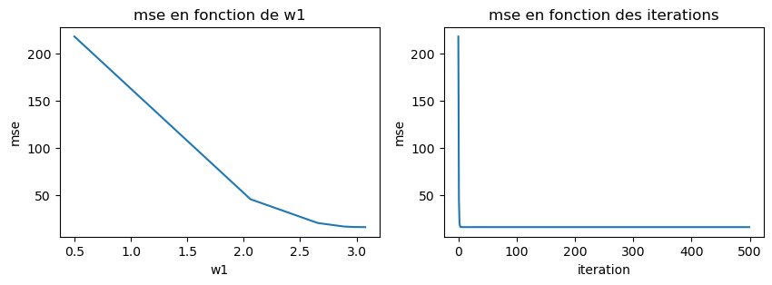

```python
def train3(X,y):
    #hyperparameters initialisation: tuning parameters
    learning_rate=0.01
    epochs=500
    #model parameters initialisation
    w1=0.5 #
    bias=1
    #----------------------
    n=len(X) #data size
    global mseList
    global w1List
    mseList=[]
    w1List=[]


    #training
    for i in range(epochs):
        yhat=bias+w1*X #prediction

        error=y-yhat # Error
        squared_error=error**2 #squared error
        mse=(1/n)*sum(squared_error) #mean squared error
        #print("(",bias, ",", w1, ") ----->",mse)
        mseList.append(mse)
        w1List.append(w1)


        dw1=(-2/n)*np.sum(X*(y-yhat)) # partial derivate of mse / w1
        dbias=(-2/n)*np.sum((y-yhat)) #partial derivate of mse / w1
        print("iteration ",i,": (bias=",round(bias,2),",w1:",round(w1,2),") --->mse=",round(mse,2)," | update: dbias=",round(dbias,2),", dw1=",round(dw1,2))
        if i%100==0:
            ploter(X,y,bias,w1)

        w1=w1-dw1*learning_rate # orientation (-) + pas d'apprentissage (l)
        bias=bias-dbias*learning_rate

    return bias,w1


#exécution
bias,w1=train3(X_train,y_train)
tracer_graphes(w1List,mseList,[i for i in range(500)])
```